# Catastrophe ELT Primer

Contents

## 1 Audience and Intent

If you have strong insurance background but catastrophe model output still feels like a black box, this document is for you.

You do not need to be a catastrophe model developer to use this document. The aim is to make the mechanics understandable enough that you can challenge assumptions, interpret outputs correctly, and communicate decisions with confidence.

In this primer, “CAT” means catastrophe. To keep language clear, the document introduces concepts in full form first, then uses short form where it helps readability.

In this primer, “ELT” means Event Loss Table.

The goal is not to impress you with abstract math. The goal is to get you comfortable with the practical questions that keep coming up in real work:

1. What does this Event Loss Table (ELT) actually imply for pricing?
2. Which metric should I use in this treaty conversation?
3. Are these tail numbers credible enough to use?
4. What do I check before trusting a vendor-style table?

This version is deliberately opinionated:

1. Intuition first, derivation where it matters.
2. R/tidyverse as canonical implementation.
3. Python parallels for key sections, with both pandas and polars.
4. Balanced treatment of occurrence XL, aggregate, and quota share.
5. Synthetic diagnostics now, real-data validation framework ready for later.

### 1.1 What this primer does and does not do

What it does:

1. Explains how to interpret catastrophe Event Loss Tables in pricing and risk decisions.
2. Shows reproducible examples that convert ELT rows into empirical decision outputs.
3. Connects analytics to governance and release-readiness controls.

What it does not do:

1. Replace detailed vendor methodology documents.
2. Claim one universal distribution or dependence model is always correct.
3. Eliminate the need for portfolio-specific validation and judgment.

### 1.2 Key terms used early in this document

| Term | Meaning |
| --- | --- |
| ELT | Event Loss Table |
| AAL | Average annual loss |
| OEP | Occurrence exceedance probability |
| AEP | Aggregate exceedance probability |
| GUL | Ground-up loss (before policy and reinsurance terms) |
| CV | Coefficient of variation, often used as $CV = \sigma/\mu$ |

### 1.3 Why catastrophe-exposed property insurance is hard

Catastrophe-exposed property insurance has a few structural challenges that make it different from many other pricing contexts:

1. Losses are highly skewed: many periods look quiet, then rare events dominate results.
2. Historical loss data is sparse at decision-relevant return periods.
3. Portfolio mix changes over time (geography, occupancy, construction, terms), so historical outcomes are not directly portable.
4. Event dependence and accumulation effects can create annual outcomes far larger than single-event intuition suggests.
5. Policy terms, reinsurance structures, and loss view definitions can change interpretation by large factors.

This is why catastrophe event loss table work is fundamentally forward-looking. The goal is not to predict one exact year; it is to build decision-grade distributions under transparent assumptions.

### 1.4 How to read this document by role

| If you are primarily… | Start here | Then go to |
| --- | --- | --- |
| Pricing/Treaty | ELT structure, occurrence exceedance probability (OEP), aggregate exceedance probability (AEP), treaty sections | Production workflow notes, advanced methods |
| Risk/Capital | OEP/AEP interpretation, empirical distributions, dependence | Extreme value theory (EVT), advanced validation backtesting |
| Model Validation/Governance | Validation and sensitivity, production workflow | Advanced validation, best practices checklist |
| Engineering/Implementation | Runtime/reproducibility, Python portability | Production workflow notes, executable index companion |

Practical reading order:

1. Read the core practical sections first.
2. Use outputs from those sections in day-to-day pricing and validation.
3. Use advanced sections only when tail, dependence, or run-time constraints require them.

### 1.5 Executive reading paths by available time

If you only have limited time, use one of these routes:

1. 10-minute path: Audience and intent -> ELT meaning in practice -> OEP/AEP quick map -> release readiness checklist.
2. 30-minute path: Add ELT structure/loss views -> empirical distribution conversion -> treaty outputs mini-case -> assumptions register.
3. Deep technical path: Read full core sections, then advanced methods and advanced validation, then production governance controls.

The purpose of these paths is not to skip rigor. It is to match depth to decision context without losing critical caveats.

## 2 Why ELTs Exist

Historical actuarial methods are powerful, but catastrophe risk has a structural problem: the most decision-relevant events are rare.

If your pricing and capital decisions depend on 1-in-100 or 1-in-250 behavior, raw claims history alone is often not enough. ELTs exist because catastrophe modeling is fundamentally prospective.

The forward-looking logic is:

1. Generate plausible stochastic event sets.
2. Map hazard to damage and damage to insured loss.
3. Encode those event-level outcomes in a compact table.
4. Simulate many annual outcomes for pricing and risk decisions.

In short: ELT is a compact machine-readable catalog of contingent futures.

## 3 What “ELT” Means in Practice

In catastrophe modeling, ELT usually means Event Loss Table.

An Event Loss Table is a row-wise representation of potential catastrophe events and their modeled loss behavior for a specific portfolio and loss view.

Two practical clarifications matter:

1. It is event-based, not year-based. The ELT does not directly tell you annual aggregate outcomes until you run a frequency-severity simulation framework over it.
2. It is portfolio-conditional. The same catalog event can have very different loss values across portfolios because exposure, terms, and geography differ.

### 3.1 Common ELT misunderstandings

| Misunderstanding | What is actually true |
| --- | --- |
| “ELT is just a historical table of observed losses” | It is a modeled prospective event table, often including events not observed in your short claims history |
| “MeanLoss is guaranteed loss if event occurs” | MeanLoss is a conditional expected value; actual event realization is distributed around it via secondary uncertainty |
| “Rate is probability of at least one event in a year” | Rate is event intensity parameter; annual event occurrence is modeled jointly through frequency assumptions |
| “One ELT number is the truth” | ELT outputs are assumption-dependent and should be interpreted with sensitivity and governance controls |

### 3.2 ELT in the broader modeling chain

Think of the pipeline as:

1. Event generation and hazard/vulnerability modeling.
2. Event-level loss representation (the ELT).
3. Annual simulation over ELT rows (aggregate exceedance probability, occurrence exceedance probability, treaty response, capital metrics).
4. Validation and governance before decision use.

This framing helps avoid a common mistake: treating ELT values as final answers rather than structured inputs to a decision model.

## 4 Generating Synthetic ELTs (Why and How)

Synthetic ELTs are useful when you need to:

1. Test workflow logic before production data is available.
2. Stress specific behaviors such as zero inflation and heavy-tail response.
3. Teach teams how ELT assumptions influence OEP, AEP, and treaty outputs.
4. Build regression tests for model pipeline and governance controls.

Synthetic does not mean unrealistic by default. The objective is controlled realism: enough structure to reproduce relevant behavior while keeping assumptions explicit.

### 4.1 Design dimensions for synthetic ELT generation

A practical synthetic ELT generator should control at least:

1. Event-rate profile (many low-rate events, fewer high-impact events).
2. Mean-loss curve shape across event ranks.
3. Secondary uncertainty scale (for example, coefficient of variation (CV) bands by severity).
4. Zero-loss share (events that do not materially impact this portfolio).
5. Optional peril or region tags for dependence experiments.

### 4.2 Minimal synthetic ELT generator pattern

```r
suppressPackageStartupMessages({
  library(tidyverse)
  library(scales)
})

seed_r_synthetic <- as.integer(Sys.getenv("SEED_R", "20260520")) + 303
set.seed(seed_r_synthetic)

generate_synthetic_elt <- function(
    n_events = 2000,
    zero_loss_share = 0.35,
    meanlog_mu = 13.2,
    meanlog_sigma = 1.2,
    rate_shape = 0.7,
    rate_scale = 0.0009) {

  event_id <- seq_len(n_events)

  # Frequency intensity pattern: many low-rate events, few higher-rate events.
  raw_rate <- rgamma(n_events, shape = rate_shape, scale = rate_scale)
  rate <- raw_rate / sum(raw_rate) * 0.75

  mean_loss <- rlnorm(n_events, meanlog = meanlog_mu, sdlog = meanlog_sigma)

  # Portfolio-specific no-impact events.
  zero_idx <- sample(event_id, size = floor(zero_loss_share * n_events), replace = FALSE)
  mean_loss[zero_idx] <- 0

  rank_pct <- rank(mean_loss, ties.method = "average") / n_events
  cv <- 0.45 + 0.9 * rank_pct
  std_dev <- mean_loss * cv

  tibble(
    event_id = event_id,
    rate = rate,
    mean_loss = mean_loss,
    std_dev = std_dev,
    cv = cv,
    is_zero_loss = mean_loss == 0
  )
}

synthetic_elt <- generate_synthetic_elt()

tibble(
  n_events = nrow(synthetic_elt),
  total_rate = sum(synthetic_elt$rate),
  zero_loss_share = mean(synthetic_elt$is_zero_loss),
  aal = sum(synthetic_elt$rate * synthetic_elt$mean_loss)
) |>
  mutate(
    total_rate = round(total_rate, 3),
    zero_loss_share = percent(zero_loss_share, accuracy = 0.01),
    aal = dollar(aal)
  ) |>
  knitr::kable()
```

| n_events | total_rate | zero_loss_share | aal |
| --- | --- | --- | --- |
| 2000 | 0.75 | 35.00% | $553,488 |

Use this as a scaffold. For production-like testing, calibrate generator parameters to benchmark portfolio diagnostics rather than using arbitrary defaults.

## 5 Runtime and Reproducibility

This document is intended to run in the containerized workflow in this repository.

That may feel operationally heavy for a primer, but reproducibility matters here: if two runs with the same settings produce materially different decisions, you have a governance problem before you have a modeling problem.

```r
library(tidyverse)
library(scales)

n_sims <- as.integer(Sys.getenv("RENDER_N_SIMS", "10000"))
seed_r <- as.integer(Sys.getenv("SEED_R", "20260520"))
seed_py <- as.integer(Sys.getenv("SEED_PY", "20260520"))
image_identity <- Sys.getenv("WORKBOOK_IMAGE_ID", "not supplied")

command_version <- function(command) {
  executable <- Sys.which(command)
  if (!nzchar(executable)) return("not found")
  paste(system2(executable, "--version", stdout = TRUE, stderr = TRUE), collapse = " ")
}

python_command <- Sys.getenv("RETICULATE_PYTHON", "python3")

set.seed(seed_r)

tibble(
  parameter = c(
    "RENDER_N_SIMS", "SEED_R", "SEED_PY", "R", "Python", "Quarto",
    "Container image"
  ),
  value = c(
    n_sims,
    seed_r,
    seed_py,
    R.version.string,
    command_version(python_command),
    command_version("quarto"),
    image_identity
  )
) |>
  knitr::kable()
```

| parameter | value |
| --- | --- |
| RENDER_N_SIMS | 10000 |
| SEED_R | 20260520 |
| SEED_PY | 20260520 |
| R | R version 4.5.1 (2025-06-13) |
| Python | Python 3.12.3 |
| Quarto | 1.7.32 |
| Container image | docker.io/rocker/tidyverse@sha256:c38f0fea583e3aa82d89d0038e5bb559a04fa813881031f61f6191e683954cf2 |

`Dockerfile` pins the base image digest, and `render.env` records the same identity for the rendered runtime. The repository has no existing `renv`, Conda, or other dependency-lock workflow; the Dockerfile’s exact Python package pins and pinned base image are therefore the supported dependency boundary here. If stochastic outputs from two runs with the same image, environment, and seeds disagree materially, treat that as a workflow warning; the live benchmark timing later in the document is intentionally nondeterministic.

## 6 ELT Structure, Variants, and Loss Views

At minimum, each ELT row has:

1. `event_id`
2. `rate`
3. `mean_loss`
4. `std_dev`

Interpretation:

1. `rate` is long-run annualized intensity.
2. `mean_loss` is conditional on event occurrence.
3. `std_dev` reflects secondary uncertainty around that conditional loss.

In plain terms: `rate` tells you how often this type of event tends to show up, `mean_loss` tells you the central loss expectation if it does, and `std_dev` tells you how noisy that event outcome can be around the center.

### 6.1 Vendor and Research Formats

| Format | Typical Columns | Notes |
| --- | --- | --- |
| Vendor-style | `summary_id, type, event_id, rate, mean_loss, standard_deviation, exposure_value` | richer metadata and linkage |
| Simplified/research | `event_id, rate, mean_loss, std_dev` | compact and easier for examples |

### 6.2 Minimum input and metadata contract

The four numeric columns are not enough to make a production ELT interpretable. Preserve this metadata alongside every extract and every rendered result:

| Metadata | Why it matters |
| --- | --- |
| Hazard, vulnerability, and financial-module model versions | Identifies the model assumptions behind the loss |
| Event-set/catalogue version and event IDs | Makes event selection and reruns reproducible |
| Exposure snapshot date, geography, and peril | Defines what the portfolio actually represents |
| Currency, valuation date, and inflation/indexation basis | Prevents scale and time-basis errors |
| Loss view and policy/reinsurance terms | Distinguishes GUL, insured, ceded, and retained results |
| Secondary-uncertainty basis and parameterization | Defines how `std_dev` becomes a loss distribution |
| Rate convention and frequency model | Clarifies whether rates are annual intensities, normalized weights, or something else |

Without this contract, a clean-looking OEP or AEP curve can still be impossible to reproduce or compare.

### 6.3 GUL vs Insured vs Net/Post-Cat

| View | Meaning | Typical Use |
| --- | --- | --- |
| GUL | ground-up physical damage loss | hazard/vulnerability diagnostics |
| Insured (pre-cat) | after policy terms, before outward reinsurance | treaty pricing and portfolio analytics |
| Net/Post-cat | after reinsurance recoveries | retained risk and capital impact |

This distinction is non-negotiable. Mixing them will break pricing and governance interpretation.

### 6.4 Toy ELT

```r
toy_elt <- tibble(
  event_id = 1:10,
  rate = c(0.14, 0.09, 0.06, 0.04, 0.025, 0.015, 0.009, 0.005, 0.002, 0.001),
  mean_loss = c(2e5, 6e5, 1.1e6, 2.8e6, 6e6, 11e6, 19e6, 35e6, 70e6, 140e6),
  std_dev = c(1e5, 3.5e5, 6e5, 1.4e6, 3.2e6, 6e6, 10e6, 18e6, 35e6, 70e6)
)

toy_elt |>
  mutate(across(c(mean_loss, std_dev), dollar)) |>
  knitr::kable()
```

| event_id | rate | mean_loss | std_dev |
| --- | --- | --- | --- |
| 1 | 0.140 | $200,000 | $100,000 |
| 2 | 0.090 | $600,000 | $350,000 |
| 3 | 0.060 | $1,100,000 | $600,000 |
| 4 | 0.040 | $2,800,000 | $1,400,000 |
| 5 | 0.025 | $6,000,000 | $3,200,000 |
| 6 | 0.015 | $11,000,000 | $6,000,000 |
| 7 | 0.009 | $19,000,000 | $10,000,000 |
| 8 | 0.005 | $35,000,000 | $18,000,000 |
| 9 | 0.002 | $70,000,000 | $35,000,000 |
| 10 | 0.001 | $140,000,000 | $70,000,000 |

## 7 Secondary Uncertainty: Distribution Choice Matters

A common mistake is treating `std_dev` as a cosmetic field. It drives tail behavior once you start pricing nonlinear structures.

In practice, this is one of the highest-leverage modeling choices in the document. Two ELTs with similar means can produce very different treaty costs and tail metrics if uncertainty shape is handled differently.

A practical way to think about it:

1. Mean controls central tendency.
2. Dispersion and shape control nonlinear pricing response.
3. Tail shape assumptions often dominate differences at high return periods.

Useful distribution options:

1. Zero-censored Normal: simple, but it creates a point mass at zero and is less natural for strong right skew.
2. Lognormal: common default, strictly positive.
3. Gamma: often convenient for right-skewed severity.
4. Beta-scaled: useful when losses are naturally bounded by layer limits.

### 7.1 Parameter conversions used frequently

For lognormal with target mean $\mu$ and std dev $\sigma$:

$$\mu_{\log} = \log\left(\frac{\mu^2}{\sqrt{\mu^2 + \sigma^2}}\right), \quad
\sigma_{\log}^2 = \log\left(1 + \frac{\sigma^2}{\mu^2}\right)$$

For gamma:

$$k = \left(\frac{\mu}{\sigma}\right)^2, \quad
\theta = \frac{\sigma^2}{\mu}$$

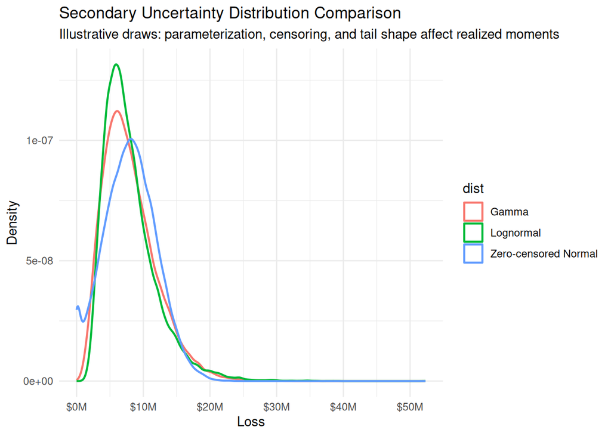

```r
mu <- 8e6
sigma <- 4e6
n_draw <- 30000
seed_r_distribution <- seed_r + 304
set.seed(seed_r_distribution)

mu_log <- log(mu^2 / sqrt(mu^2 + sigma^2))
sigma_log <- sqrt(log(1 + sigma^2 / mu^2))

k_gamma <- (mu / sigma)^2
theta_gamma <- sigma^2 / mu

draw_tbl <- bind_rows(
  tibble(dist = "Zero-censored Normal", loss = pmax(0, rnorm(n_draw, mu, sigma))),
  tibble(dist = "Lognormal", loss = rlnorm(n_draw, mu_log, sigma_log)),
  tibble(dist = "Gamma", loss = rgamma(n_draw, shape = k_gamma, scale = theta_gamma))
)

ggplot(draw_tbl, aes(x = loss, color = dist)) +
  geom_density(linewidth = 0.8) +
  scale_x_continuous(labels = dollar_format(scale = 1e-6, suffix = "M")) +
  labs(
    title = "Secondary Uncertainty Distribution Comparison",
    subtitle = "Illustrative draws: parameterization, censoring, and tail shape affect realized moments",
    x = "Loss",
    y = "Density"
  ) +
  theme_minimal()
```

```r
realized_moments_tbl <- draw_tbl |>
  group_by(dist) |>
  summarise(
    realized_mean = mean(loss),
    realized_sd = sd(loss),
    zero_mass = mean(loss == 0),
    .groups = "drop"
  ) |>
  mutate(
    realized_mean = dollar(realized_mean),
    realized_sd = dollar(realized_sd),
    zero_mass = percent(zero_mass, accuracy = 0.01)
  )

realized_moments_tbl |>
  knitr::kable(col.names = c("Distribution", "Realized mean", "Realized std. dev.", "Zero mass"))
```

| Distribution | Realized mean | Realized std. dev. | Zero mass |
| --- | --- | --- | --- |
| Gamma | $8,025,819 | $4,008,472 | 0.00% |
| Lognormal | $7,974,995 | $3,979,033 | 0.00% |
| Zero-censored Normal | $7,981,987 | $3,928,995 | 2.45% |

`pmax(0, rnorm(...))` is not a truncated normal. It censors negative draws at zero, so it adds a point mass at zero and no longer preserves the requested mean and standard deviation. Use a calibrated truncated distribution when those moments matter. The unbounded lognormal and gamma examples can also exceed exposure or contractual caps; apply those caps explicitly before using them in treaty calculations.

## 8 OEP and AEP: Choosing the Right Lens

OEP and AEP answer different questions, and confusion between them is one of the most common interpretation errors in practice.

Use OEP when you are discussing single-event stress and occurrence protection. Use AEP when you are discussing annual accumulation and capital volatility.

If a meeting ever mixes these two without saying which lens is active, pause and clarify before making decisions. Many expensive misinterpretations start exactly there.

### 8.1 Metric-to-decision quick map

| Metric | Best used for | Typical pitfall if misused |
| --- | --- | --- |
| AAL | Budgeting, portfolio-level expected cost context | Treated as a tail risk metric |
| OEP | Occurrence reinsurance and single-event stress | Used to represent annual accumulation |
| AEP | Capital and annual volatility discussions | Used without checking dependence and event-count assumptions |
| P99/P99.5 | High-tail decision boundaries | Treated as stable without sensitivity evidence |

Use this map as a guardrail before discussing outputs with pricing committees or risk governance.

### 8.2 OEP (single-event lens)

The simplest teaching curve thresholds the conditional mean loss. That is a useful approximation, but it is not the full secondary-uncertainty OEP:

$$\text{mean-loss OEP}(x) = 1 - \exp\left(-\sum_{i: \mu_i \ge x} \text{rate}_i\right)$$

When secondary uncertainty is modelled, the exceedance probability for event $i$ is conditional on that event occurring:

$$\text{OEP}(x) = 1 - \exp\left(-\sum_i \text{rate}_i P(L_i > x \mid i)\right)$$

Use the stochastic form for treaty and capital decisions. Keep the mean-loss curve as a diagnostic so readers can see how much secondary uncertainty changes the result.

```r
validate_severity_inputs <- function(mu, sigma) {
  if (length(mu) != 1L || length(sigma) != 1L ||
      !is.numeric(mu) || !is.numeric(sigma) ||
      !is.finite(mu) || !is.finite(sigma) || mu < 0 || sigma < 0) {
    stop("Severity inputs must be finite, scalar, and non-negative: mu >= 0 and sigma >= 0.", call. = FALSE)
  }
  invisible(TRUE)
}

severity_model <- function(mu, sigma) {
  validate_severity_inputs(mu, sigma)

  if (mu == 0) return(list(type = "zero", mu = mu, sigma = sigma))
  if (sigma == 0) return(list(type = "deterministic", mu = mu, sigma = sigma))

  list(
    type = "lognormal",
    mu = mu,
    sigma = sigma,
    meanlog = log(mu^2 / sqrt(mu^2 + sigma^2)),
    sdlog = sqrt(log1p(sigma^2 / mu^2))
  )
}

simulate_severity <- function(mu, sigma, n = 1L) {
  if (length(n) != 1L || !is.numeric(n) || !is.finite(n) || n < 1 || n != as.integer(n)) {
    stop("Severity draw count must be a positive integer.", call. = FALSE)
  }

  model <- severity_model(mu, sigma)
  n <- as.integer(n)
  switch(
    model$type,
    zero = rep(0, n),
    deterministic = rep(model$mu, n),
    lognormal = rlnorm(n, model$meanlog, model$sdlog)
  )
}

severity_tail <- function(x, mu, sigma) {
  if (length(x) != 1L || !is.numeric(x) || !is.finite(x)) {
    stop("Severity threshold x must be one finite numeric value.", call. = FALSE)
  }

  model <- severity_model(mu, sigma)
  if (model$type == "zero") return(as.numeric(0 > x))
  if (model$type == "deterministic") return(as.numeric(model$mu > x))
  if (x < 0) return(1)

  plnorm(x, meanlog = model$meanlog, sdlog = model$sdlog, lower.tail = FALSE)
}

validate_elt_inputs <- function(elt_tbl) {
  required <- c("rate", "mean_loss", "std_dev")
  if (!all(required %in% names(elt_tbl))) {
    stop("ELT must contain rate, mean_loss, and std_dev columns.", call. = FALSE)
  }
  if (any(!is.finite(elt_tbl$rate)) || any(elt_tbl$rate < 0) || sum(elt_tbl$rate) <= 0) {
    stop("ELT rates must be finite, non-negative, and have a positive total.", call. = FALSE)
  }
  walk2(elt_tbl$mean_loss, elt_tbl$std_dev, severity_model)
  invisible(TRUE)
}

lognormal_tail <- function(x, mu, sigma) {
  severity_tail(x, mu, sigma)
}

stochastic_oep_at <- function(x, elt_tbl) {
  validate_elt_inputs(elt_tbl)
  exceedance_rate <- sum(map_dbl(seq_len(nrow(elt_tbl)), function(i) {
    elt_tbl$rate[[i]] * lognormal_tail(x, elt_tbl$mean_loss[[i]], elt_tbl$std_dev[[i]])
  }))
  1 - exp(-exceedance_rate)
}

mean_loss_oep_tbl <- toy_elt |>
  group_by(mean_loss) |>
  summarise(
    rate = sum(rate),
    event_count = n(),
    .groups = "drop"
  ) |>
  arrange(desc(mean_loss)) |>
  mutate(
    cumulative_rate = cumsum(rate),
    mean_loss_oep = 1 - exp(-cumulative_rate),
    stochastic_oep = map_dbl(mean_loss, ~ stochastic_oep_at(.x, toy_elt)),
    return_period = 1 / stochastic_oep
  )

mean_loss_oep_tbl |>
  transmute(
    mean_loss = dollar(mean_loss),
    event_count,
    mean_loss_oep = percent(mean_loss_oep, accuracy = 0.01),
    stochastic_oep = percent(stochastic_oep, accuracy = 0.01),
    return_period = round(return_period, 1)
  ) |>
  knitr::kable(col.names = c("Mean loss", "Tied events", "Mean-loss OEP", "Stochastic OEP", "Return Period"))
```

| Mean loss | Tied events | Mean-loss OEP | Stochastic OEP | Return Period |
| --- | --- | --- | --- | --- |
| $140,000,000 | 1 | 0.10% | 0.05% | 2000.6 |
| $70,000,000 | 1 | 0.30% | 0.20% | 511.1 |
| $35,000,000 | 1 | 0.80% | 0.55% | 182.0 |
| $19,000,000 | 1 | 1.69% | 1.23% | 81.4 |
| $11,000,000 | 1 | 3.15% | 2.27% | 44.0 |
| $6,000,000 | 1 | 5.54% | 3.97% | 25.2 |
| $2,800,000 | 1 | 9.24% | 6.93% | 14.4 |
| $1,100,000 | 1 | 14.53% | 11.90% | 8.4 |
| $600,000 | 1 | 21.89% | 16.69% | 6.0 |
| $200,000 | 1 | 32.09% | 25.94% | 3.9 |

### 8.3 AEP (annual aggregate lens)

Aggregate exceedance probability captures annual accumulation risk.

This example uses a deliberately narrow model contract: independent Poisson event counts, event types sampled with replacement in proportion to their rates, lognormal secondary uncertainty, and no seasonality, clustering, event-set dependence, climate non-stationarity, or cross-peril dependence. Repeated draws of one catalogue row represent repeated occurrences of the same event type, not the same physical event. Those assumptions are useful for teaching the mechanics; they are not universal catastrophe-model assumptions.

```r
seed_r_annual <- seed_r + 305
set.seed(seed_r_annual)

simulate_year <- function(elt_tbl) {
  validate_elt_inputs(elt_tbl)
  lambda <- sum(elt_tbl$rate)
  n_events <- rpois(1, lambda)
  if (n_events == 0) return(c(aggregate = 0, maximum = 0))

  event_idx <- sample(
    seq_len(nrow(elt_tbl)),
    size = n_events,
    replace = TRUE,
    prob = elt_tbl$rate
  )

  losses <- map_dbl(event_idx, function(i) {
    simulate_severity(elt_tbl$mean_loss[[i]], elt_tbl$std_dev[[i]])[[1]]
  })

  c(aggregate = sum(losses), maximum = max(losses))
}

annual_sim <- replicate(n_sims, simulate_year(toy_elt), simplify = TRUE)
annual_losses <- as.numeric(annual_sim["aggregate", ])
annual_maxima <- as.numeric(annual_sim["maximum", ])

aep_tbl <- tibble(return_period = c(10, 25, 50, 100, 250)) |>
  mutate(aep_loss = quantile(annual_losses, probs = 1 - 1 / return_period))

aep_tbl |>
  mutate(aep_loss = dollar(aep_loss)) |>
  knitr::kable(col.names = c("Return Period", "AEP Loss"))
```

| Return Period | AEP Loss |
| --- | --- |
| 10 | $1,530,282 |
| 25 | $6,519,286 |
| 50 | $13,102,309 |
| 100 | $25,492,823 |
| 250 | $50,089,368 |

For a stochastic OEP, return-period inversion solves the probability equation directly. Targets outside the attainable non-negative-loss boundary are returned as `NA` with an explicit status; they are never silently clamped to a nearby event loss.

```r
lookup_oep_loss <- function(target_ep, elt_tbl, initial_upper = NULL, max_expansions = 60L) {
  validate_elt_inputs(elt_tbl)

  if (length(target_ep) != 1L || !is.numeric(target_ep) || !is.finite(target_ep) ||
      target_ep < 0 || target_ep > 1) {
    return(list(loss = NA_real_, status = "invalid_target_ep", target_ep = target_ep))
  }

  ep_at_zero <- stochastic_oep_at(0, elt_tbl)
  if (target_ep > ep_at_zero) {
    return(list(
      loss = NA_real_,
      status = "target_above_zero_loss_boundary",
      target_ep = target_ep,
      boundary_ep = ep_at_zero
    ))
  }
  if (target_ep == 0) {
    return(list(
      loss = NA_real_,
      status = "target_at_infinite_loss_boundary",
      target_ep = target_ep,
      boundary_ep = 0
    ))
  }
  if (isTRUE(all.equal(target_ep, ep_at_zero))) {
    return(list(
      loss = 0,
      status = "lower_boundary",
      target_ep = target_ep,
      boundary_ep = ep_at_zero
    ))
  }

  upper <- if (is.null(initial_upper)) max(c(elt_tbl$mean_loss, 1), na.rm = TRUE) else initial_upper
  if (!is.finite(upper) || upper <= 0) upper <- 1
  upper <- max(upper, 1)
  expansions <- 0L
  f <- function(loss) stochastic_oep_at(loss, elt_tbl) - target_ep

  while (f(upper) > 0 && expansions < max_expansions && upper < .Machine$double.xmax / 2) {
    upper <- upper * 2
    expansions <- expansions + 1L
  }

  if (f(upper) > 0) {
    return(list(
      loss = NA_real_,
      status = "upper_bound_not_found",
      target_ep = target_ep,
      upper_bound = upper,
      expansions = expansions
    ))
  }

  root <- uniroot(f, interval = c(0, upper), extendInt = "no")$root
  list(
    loss = root,
    status = "ok",
    target_ep = target_ep,
    oep_at_loss = stochastic_oep_at(root, elt_tbl),
    upper_bound = upper,
    expansions = expansions
  )
}

mc_quantile_se <- function(x, prob, n_boot = 40L) {
  replicate(n_boot, quantile(sample(x, replace = TRUE), prob = prob)) |>
    sd()
}

safe_aep_oep_point <- function(target_ep, annual_aggregate, annual_maximum, elt_tbl) {
  oep <- lookup_oep_loss(target_ep, elt_tbl)
  if (!identical(oep$status, "ok")) {
    return(tibble(
      oep_loss = NA_real_, aep_loss = NA_real_, oep_mc_loss = NA_real_,
      mc_tolerance = NA_real_, comparison_status = oep$status
    ))
  }

  aep_estimate <- as.numeric(quantile(annual_aggregate, probs = 1 - target_ep))
  oep_mc_estimate <- as.numeric(quantile(annual_maximum, probs = 1 - target_ep))
  mc_tolerance <- 2 * (
    mc_quantile_se(annual_aggregate, 1 - target_ep) +
      mc_quantile_se(annual_maximum, 1 - target_ep)
  )
  aggregate_maximum_ok <- aep_estimate + mc_tolerance >= oep_mc_estimate
  theoretical_mc_ok <- abs(oep$loss - oep_mc_estimate) <= mc_tolerance
  raw_order_ok <- aep_estimate >= oep$loss
  comparison_status <- if (!aggregate_maximum_ok || !theoretical_mc_ok) {
    "invariant_fail"
  } else if (!raw_order_ok) {
    "within_mc_tolerance_aep_below_oep"
  } else {
    "pass"
  }

  display_ok <- identical(comparison_status, "pass")
  tibble(
    oep_loss = if (display_ok) oep$loss else NA_real_,
    aep_loss = if (display_ok) aep_estimate else NA_real_,
    oep_mc_loss = oep_mc_estimate,
    mc_tolerance = mc_tolerance,
    comparison_status = comparison_status
  )
}

seed_r_mc_diagnostics <- seed_r + 505
set.seed(seed_r_mc_diagnostics)

mc_diagnostics_tbl <- tibble(
  metric = c("AAL", "P99 annual", "P99.5 annual"),
  estimate = c(
    mean(annual_losses),
    quantile(annual_losses, 0.99),
    quantile(annual_losses, 0.995)
  ),
  tail_observations = c(
    n_sims,
    sum(annual_losses >= quantile(annual_losses, 0.99)),
    sum(annual_losses >= quantile(annual_losses, 0.995))
  ),
  mc_se = c(
    sd(annual_losses) / sqrt(n_sims),
    mc_quantile_se(annual_losses, 0.99),
    mc_quantile_se(annual_losses, 0.995)
  )
) |>
  mutate(
    estimate = dollar(estimate),
    mc_se = dollar(mc_se)
  )

mc_diagnostics_tbl |>
  knitr::kable(col.names = c("Metric", "Estimate", "Tail observations", "Bootstrap/MC SE"))
```

| Metric | Estimate | Tail observations | Bootstrap/MC SE |
| --- | --- | --- | --- |
| AAL | $1,269,695 | 10000 | $81,831 |
| P99 annual | $25,492,823 | 100 | $1,907,873 |
| P99.5 annual | $41,029,335 | 50 | $4,400,489 |

Treat these diagnostics as part of the result, not as optional decoration. A 10,000-year development run has only about 40 observations beyond a 1-in-250 annual quantile; even the 100,000-year full run has only a few hundred observations in the far tail. Increase simulation depth, use replicated seeds, or compare with an independently fitted tail model before treating high return periods as stable.

### 8.4 OEP vs AEP side-by-side interpretation

The table below is the practical cross-check: for the same return period, how different are OEP and AEP in this portfolio shape?

If the AEP/OEP ratio is materially above 1 at the return periods you care about, annual accumulation effects are economically important and should not be handled as an afterthought.

```r
seed_r_oep_aep_check <- seed_r + 506
set.seed(seed_r_oep_aep_check)

comparison_tbl <- tibble(return_period = c(10, 25, 50, 100, 250)) |>
  mutate(target_ep = 1 / return_period) |>
  mutate(check = map(target_ep, ~ safe_aep_oep_point(.x, annual_losses, annual_maxima, toy_elt))) |>
  unnest_wider(check) |>
  mutate(ratio_aep_to_oep = if_else(comparison_status == "pass", aep_loss / oep_loss, NA_real_))

comparison_tbl |>
  mutate(
    oep_loss = dollar(oep_loss),
    aep_loss = dollar(aep_loss),
    ratio_aep_to_oep = round(ratio_aep_to_oep, 2)
  ) |>
  select(return_period, oep_loss, aep_loss, oep_mc_loss, mc_tolerance, ratio_aep_to_oep, comparison_status) |>
  mutate(
    oep_mc_loss = dollar(oep_mc_loss),
    mc_tolerance = dollar(mc_tolerance)
  ) |>
  knitr::kable(col.names = c("Return Period", "OEP Loss", "AEP Loss", "MC OEP check", "MC tolerance", "AEP/OEP", "Invariant status"))
```

| Return Period | OEP Loss | AEP Loss | MC OEP check | MC tolerance | AEP/OEP | Invariant status |
| --- | --- | --- | --- | --- | --- | --- |
| 10 | $1,495,384 | $1,530,282 | $1,419,788 | $335,044 | 1.02 | pass |
| 25 | $5,948,150 | $6,519,286 | $6,081,156 | $1,509,849 | 1.10 | pass |
| 50 | $12,422,110 | $13,102,309 | $12,827,508 | $2,816,224 | 1.05 | pass |
| 100 | $22,397,868 | $25,492,823 | $25,013,821 | $8,513,228 | 1.14 | pass |
| 250 | $43,740,671 | $50,089,368 | $49,236,537 | $20,616,610 | 1.15 | pass |

Under the stated non-negative compound-Poisson contract, annual aggregate loss is pathwise at least the annual maximum loss. The comparison therefore simulates both quantities from the same annual draws, checks the stochastic OEP root against the simulated annual maximum, and suppresses OEP/AEP values and ratios when the ordering fails beyond twice the combined bootstrap Monte Carlo standard error. `within_mc_tolerance_aep_below_oep` is reported as a review status rather than a numeric ratio below one.

## 9 Treaty Structures in One Place

Treaty structures are easiest to understand when you map each one to the risk question it is trying to control:

1. Occurrence XL controls the single-event shock profile.
2. Quota share proportionally scales ceded and retained severity exposure; the underlying event frequency is unchanged unless the cession scope changes.
3. Aggregate structures cap annual accumulation.

For event loss $L$, attachment $A$, and limit $U$, occurrence XL recovery is:

$$\text{recover}(L) = \min(\max(L-A, 0), U)$$

For quota share with cession $q$, ceded loss is $qL$ and net is $(1-q)L$. Aggregate stop-loss style treatment is then applied to annual aggregated loss, not event-level loss.

The table below is intentionally simplified. Real treaty calculations also need exclusions, cession limits, commissions, reinstatements, inuring order, occurrence definitions, and an explicit decision about whether terms apply per occurrence, per event, or in the aggregate.

The worked table below keeps all three in one place so you can compare structural response rather than reviewing three disconnected definitions.

This is also where teams often discover they are talking past each other: one side discussing event-level protection and the other discussing annual aggregate impact. Keeping all three side by side reduces that failure mode.

```r
attachment <- 10e6
limit <- 20e6
qs <- 0.30

structure_tbl <- tibble(event_loss = c(5e6, 14e6, 22e6, 50e6)) |>
  mutate(
    occ_xl_recovery = pmin(pmax(event_loss - attachment, 0), limit),
    occ_xl_net = event_loss - occ_xl_recovery,
    qs_recovery = qs * event_loss,
    qs_net = (1 - qs) * event_loss
  )

structure_tbl |>
  mutate(across(everything(), dollar)) |>
  knitr::kable()
```

| event_loss | occ_xl_recovery | occ_xl_net | qs_recovery | qs_net |
| --- | --- | --- | --- | --- |
| $5,000,000 | $0 | $5,000,000 | $1,500,000 | $3,500,000 |
| $14,000,000 | $4,000,000 | $10,000,000 | $4,200,000 | $9,800,000 |
| $22,000,000 | $12,000,000 | $10,000,000 | $6,600,000 | $15,400,000 |
| $50,000,000 | $20,000,000 | $30,000,000 | $15,000,000 | $35,000,000 |

## 10 Python Portability (pandas + polars)

This section is deliberately practical: first show that pandas and polars produce equivalent OEP mechanics on a small table, then show a large-table pattern where engine choice may affect run time.

The goal is not to claim one engine is universally better. The goal is to keep numerical semantics stable while you optimize execution path by workload.

### 10.1 Small-table mean-loss OEP parity check

This is mean-loss OEP parity: both engines apply the cumulative-rate formula to conditional mean losses. It is not stochastic secondary-uncertainty OEP, and it is not annual occurrence pricing.

```python
import os
import numpy as np
import pandas as pd
import polars as pl

pdf = pd.DataFrame({
    "event_id": [1, 2, 3, 4, 5],
    "rate": [0.10, 0.05, 0.025, 0.01, 0.004],
    "mean_loss": [1.5e6, 4e6, 9e6, 20e6, 45e6]
}).sort_values("mean_loss", ascending=False)

pdf["cumulative_rate"] = pdf["rate"].cumsum()
pdf["oep"] = 1 - np.exp(-pdf["cumulative_rate"])

pldf = pl.from_pandas(pdf)
pldf = pldf.with_columns([
    pl.col("rate").cum_sum().alias("cumulative_rate"),
]).with_columns([
    (1 - (-pl.col("cumulative_rate")).exp()).alias("oep")
])

pdf[["event_id", "mean_loss", "oep"]], pldf.select(["event_id", "mean_loss", "oep"])
```

```
(   event_id   mean_loss       oep
4         5  45000000.0  0.003992
3         4  20000000.0  0.013902
2         3   9000000.0  0.038249
1         2   4000000.0  0.085154
0         1   1500000.0  0.172213, shape: (5, 3)
┌──────────┬───────────┬──────────┐
│ event_id ┆ mean_loss ┆ oep      │
│ ---      ┆ ---       ┆ ---      │
│ i64      ┆ f64       ┆ f64      │
╞══════════╪═══════════╪══════════╡
│ 5        ┆ 4.5e7     ┆ 0.003992 │
│ 4        ┆ 2e7       ┆ 0.013902 │
│ 3        ┆ 9e6       ┆ 0.038249 │
│ 2        ┆ 4e6       ┆ 0.085154 │
│ 1        ┆ 1.5e6     ┆ 0.172213 │
└──────────┴───────────┴──────────┘)
```

### 10.2 Large-table benchmark pattern (workload dependent)

The timing output is a live local benchmark and is intentionally nondeterministic; use it only to illustrate measurement and workload dependence, not as a reproducible performance claim.

```python
from time import perf_counter

seed_py = int(os.environ.get("SEED_PY", "20260520"))
rng = np.random.default_rng(seed_py)
n = 300_000

pdf_big = pd.DataFrame(
    {
        "event_id": np.arange(1, n + 1),
        "rate": rng.gamma(shape=0.7, scale=0.0008, size=n),
        "mean_loss": rng.lognormal(mean=13.4, sigma=1.1, size=n),
    }
)

t0 = perf_counter()
pandas_oep = (
    pdf_big.sort_values("mean_loss", ascending=False)
    .assign(cumulative_rate=lambda x: x["rate"].cumsum())
    .assign(oep=lambda x: 1 - np.exp(-x["cumulative_rate"]))
)
t1 = perf_counter()

pl_big = pl.from_pandas(pdf_big)
t2 = perf_counter()
polars_oep = (
    pl_big.sort("mean_loss", descending=True)
    .with_columns(pl.col("rate").cum_sum().alias("cumulative_rate"))
    .with_columns((1 - (-pl.col("cumulative_rate")).exp()).alias("oep"))
)
t3 = perf_counter()

timing_df = pd.DataFrame(
    {
        "engine": ["pandas", "polars"],
        "seconds": [round(t1 - t0, 4), round(t3 - t2, 4)],
    }
)

timing_df, polars_oep.select(["event_id", "mean_loss", "oep"]).head(5)
```

```
(   engine  seconds
0  pandas   0.0160
1  polars   0.0115, shape: (5, 3)
┌──────────┬───────────┬──────────┐
│ event_id ┆ mean_loss ┆ oep      │
│ ---      ┆ ---       ┆ ---      │
│ i64      ┆ f64       ┆ f64      │
╞══════════╪═══════════╪══════════╡
│ 243978   ┆ 9.7456e7  ┆ 0.000063 │
│ 160582   ┆ 8.3833e7  ┆ 0.00007  │
│ 291580   ┆ 8.0685e7  ┆ 0.001005 │
│ 242518   ┆ 6.7617e7  ┆ 0.001248 │
│ 275912   ┆ 6.4105e7  ┆ 0.001426 │
└──────────┴───────────┴──────────┘)
```

Interpret timing carefully.

1. This is a local illustrative benchmark, not a universal ranking.
2. Data shape, grouping complexity, and memory pressure can change the result.
3. Choose engine per pipeline segment, not by one microbenchmark.

## 11 From ELT to Empirical Distributions

This is the bridge from row-level ELT data to decision-level distributions.

Event-level sampling helps explain what one event can do. Annual aggregation shows what the portfolio can do over a year when multiple events combine.

Both views are needed: one for occurrence design and one for accumulation design.

### 11.1 Step 1: Build an empirical event-loss sample

At event level, two random elements are sampled jointly:

1. Which event occurs (weighted by event rate).
2. What conditional loss realization occurs for that event.

That produces an empirical event-loss distribution suitable for occurrence-oriented pricing questions.

```r
seed_r_event_samples <- seed_r + 403
set.seed(seed_r_event_samples)

generate_event_samples <- function(elt_tbl, n_samples = 30000) {
  validate_elt_inputs(elt_tbl)
  probs <- elt_tbl$rate / sum(elt_tbl$rate)
  idx <- sample(seq_len(nrow(elt_tbl)), n_samples, replace = TRUE, prob = probs)

  losses <- map_dbl(idx, function(i) {
    simulate_severity(elt_tbl$mean_loss[[i]], elt_tbl$std_dev[[i]])[[1]]
  })

  tibble(event_id = elt_tbl$event_id[idx], loss = losses)
}

conditional_event_dist_tbl <- generate_event_samples(toy_elt, n_samples = 50000)
annual_dist_tbl <- tibble(loss = annual_losses)

event_quant_tbl <- tibble(
  percentile = c(0.50, 0.75, 0.90, 0.95, 0.99),
  conditional_event_loss = quantile(conditional_event_dist_tbl$loss, probs = percentile)
) |>
  mutate(conditional_event_loss = dollar(conditional_event_loss))

event_quant_tbl |>
  knitr::kable(col.names = c("Percentile", "Conditional event loss"))
```

| Percentile | Conditional event loss |
| --- | --- |
| 0.50 | $530,486 |
| 0.75 | $1,717,722 |
| 0.90 | $6,236,269 |
| 0.95 | $12,498,144 |
| 0.99 | $43,335,270 |

### 11.2 Step 2: Build the empirical annual aggregate sample

`annual_losses` is the annual aggregate sample in this primer. Converting it into quantiles provides the practical inputs most committees actually review.

```r
annual_quant_tbl <- tibble(
  percentile = c(0.50, 0.75, 0.90, 0.95, 0.99, 0.995),
  annual_loss = quantile(annual_losses, probs = percentile)
) |>
  mutate(annual_loss = dollar(annual_loss))

annual_quant_tbl |>
  knitr::kable(col.names = c("Percentile", "Annual empirical loss"))
```

| Percentile | Annual empirical loss |
| --- | --- |
| 0.500 | $0 |
| 0.750 | $212,077 |
| 0.900 | $1,530,282 |
| 0.950 | $4,733,734 |
| 0.990 | $25,492,823 |
| 0.995 | $41,029,335 |

### 11.3 Step 3: Compare event and annual views directly

```r
comparison_empirical <- tibble(
  percentile = c(0.90, 0.95, 0.99),
  conditional_event_loss = quantile(conditional_event_dist_tbl$loss, probs = percentile),
  annual_loss = quantile(annual_losses, probs = percentile),
  annual_to_conditional_ratio = annual_loss / conditional_event_loss
) |>
  mutate(
    conditional_event_loss = dollar(conditional_event_loss),
    annual_loss = dollar(annual_loss),
    annual_to_conditional_ratio = round(annual_to_conditional_ratio, 2)
  )

comparison_empirical |>
  knitr::kable(col.names = c("Percentile", "Conditional Event Loss", "Annual Loss", "Annual/Conditional Ratio"))
```

| Percentile | Conditional Event Loss | Annual Loss | Annual/Conditional Ratio |
| --- | --- | --- | --- |
| 0.90 | $6,236,269 | $1,530,282 | 0.25 |
| 0.95 | $12,498,144 | $4,733,734 | 0.38 |
| 0.99 | $43,335,270 | $25,492,823 | 0.59 |

Interpretation:

1. This is a scale comparison, not an OEP/AEP comparison: the two samples live in different probability spaces.
2. Ratios above 1 can indicate accumulation pressure, but they do not carry a return-period interpretation by themselves.
3. Use the annual sample for AEP and the rate-weighted conditional tails for OEP.

### 11.4 Step 4: Visualize shape differences

The density view below is useful when explaining to non-technical stakeholders why event and annual perspectives can produce different decisions.

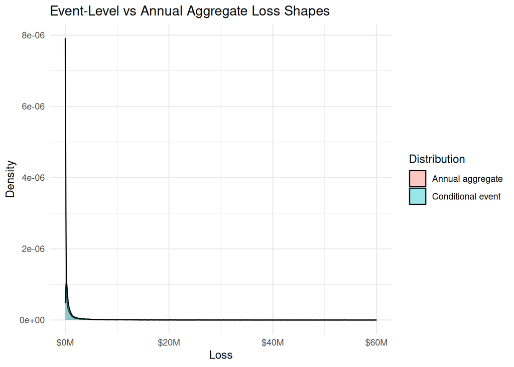

```r
bind_rows(
  conditional_event_dist_tbl |> select(loss) |> mutate(type = "Conditional event"),
  annual_dist_tbl |> mutate(type = "Annual aggregate")
) |>
  ggplot(aes(x = loss, fill = type)) +
  geom_density(alpha = 0.4) +
  scale_x_continuous(labels = dollar_format(scale = 1e-6, suffix = "M"), limits = c(0, 60e6)) +
  labs(
    title = "Event-Level vs Annual Aggregate Loss Shapes",
    x = "Loss",
    y = "Density",
    fill = "Distribution"
  ) +
  theme_minimal()
```

### 11.5 Step 5: Convert empirical samples to exceedance views

For decision processes that use exceedance and return-period language, keep annual EP/RP and conditional event tails separate. The annual sample supports AEP; OEP should use the rate-weighted conditional tail formula above.

Here, exceedance probability (EP) is the share of simulated losses above a threshold, and return period (RP) is approximately $RP = 1/EP$.

```r
thresholds <- quantile(annual_losses, probs = seq(0.80, 0.995, by = 0.015))

emp_ep_tbl <- tibble(threshold = as.numeric(thresholds)) |>
  mutate(
    annual_ep = map_dbl(threshold, ~ mean(annual_losses > .x)),
    stochastic_oep = map_dbl(threshold, ~ stochastic_oep_at(.x, toy_elt)),
    conditional_event_tail = map_dbl(threshold, ~ mean(conditional_event_dist_tbl$loss > .x)),
    annual_rp = 1 / pmax(annual_ep, 1e-9)
  )

emp_ep_tbl |>
  transmute(
    threshold = dollar(threshold),
    annual_ep = percent(annual_ep, accuracy = 0.01),
    stochastic_oep = percent(stochastic_oep, accuracy = 0.01),
    conditional_event_tail = percent(conditional_event_tail, accuracy = 0.01),
    annual_rp = round(annual_rp, 1)
  ) |>
  head(12) |>
  knitr::kable(col.names = c("Threshold", "Annual EP", "Stochastic OEP", "Conditional Event Tail", "Annual RP"))
```

| Threshold | Annual EP | Stochastic OEP | Conditional Event Tail | Annual RP |
| --- | --- | --- | --- | --- |
| $400,215 | 20.00% | 19.92% | 57.14% | 5.0 |
| $486,664 | 18.50% | 18.39% | 52.14% | 5.4 |
| $596,188 | 17.00% | 16.74% | 47.05% | 5.9 |
| $703,465 | 15.50% | 15.37% | 42.93% | 6.5 |
| $847,809 | 14.00% | 13.84% | 38.28% | 7.1 |
| $1,038,706 | 12.50% | 12.30% | 33.69% | 8.0 |
| $1,297,084 | 11.00% | 10.83% | 29.36% | 9.1 |
| $1,711,760 | 9.50% | 9.28% | 25.04% | 10.5 |
| $2,303,081 | 8.00% | 7.83% | 20.84% | 12.5 |
| $3,322,327 | 6.50% | 6.18% | 16.32% | 15.4 |
| $4,733,734 | 5.00% | 4.79% | 12.52% | 20.0 |
| $7,443,807 | 3.50% | 3.30% | 8.48% | 28.6 |

This is usually the handoff point: empirical annual and occurrence exceedance outputs with clear assumptions and sensitivity context. The conditional event tail is shown for scale only; it is not an annual probability or return period.

### 11.6 End-to-end mini-case: synthetic ELT to treaty outputs

This compact case stitches the full chain together in one place:

1. Start from synthetic ELT rows.
2. Simulate empirical annual losses.
3. Build OEP and AEP points.
4. Translate losses into occurrence and aggregate treaty response.

```r
seed_r_mini_annual <- seed_r + 404
set.seed(seed_r_mini_annual)

mini_elt <- synthetic_elt |>
  select(event_id, rate, mean_loss, std_dev)

mini_annual_sim <- replicate(n_sims, simulate_year(mini_elt), simplify = TRUE)
mini_annual_losses <- as.numeric(mini_annual_sim["aggregate", ])
mini_annual_maxima <- as.numeric(mini_annual_sim["maximum", ])

# OEP uses rate-weighted conditional secondary-uncertainty tails.
mini_oep_tbl <- mini_elt |>
  group_by(mean_loss) |>
  summarise(rate = sum(rate), event_count = n(), .groups = "drop") |>
  arrange(desc(mean_loss)) |>
  mutate(
    cumulative_rate = cumsum(rate),
    mean_loss_oep = 1 - exp(-cumulative_rate),
    stochastic_oep = map_dbl(mean_loss, ~ stochastic_oep_at(.x, mini_elt))
  )

rp_targets <- c(10, 25, 50, 100, 250)

mini_points_tbl <- tibble(return_period = rp_targets) |>
  mutate(ep = 1 / return_period)

seed_r_mini_oep_check <- seed_r + 406
set.seed(seed_r_mini_oep_check)
mini_points_tbl <- mini_points_tbl |>
  mutate(check = map(ep, ~ safe_aep_oep_point(.x, mini_annual_losses, mini_annual_maxima, mini_elt))) |>
  unnest_wider(check)

# Treaty response examples.
occ_attach <- 12e6
occ_limit <- 18e6
agg_attach <- 65e6
agg_limit <- 45e6

agg_recovery <- pmin(pmax(mini_annual_losses - agg_attach, 0), agg_limit)

validate_layer_inputs <- function(attachment, limit) {
  if (length(attachment) != 1L || length(limit) != 1L ||
      !is.numeric(attachment) || !is.numeric(limit) ||
      !is.finite(attachment) || !is.finite(limit) || attachment < 0 || limit < 0) {
    stop("Treaty attachment and limit must be finite, scalar, and non-negative.", call. = FALSE)
  }
  invisible(TRUE)
}

lognormal_stop_loss <- function(model, threshold) {
  if (threshold <= 0) return(model$mu)
  model$mu * pnorm((model$meanlog + model$sdlog^2 - log(threshold)) / model$sdlog) -
    threshold * pnorm((model$meanlog - log(threshold)) / model$sdlog)
}

conditional_treaty_stats <- function(elt_tbl, attachment, limit) {
  validate_elt_inputs(elt_tbl)
  validate_layer_inputs(attachment, limit)

  by_event <- map_dfr(seq_len(nrow(elt_tbl)), function(i) {
    mu <- elt_tbl$mean_loss[[i]]
    sigma <- elt_tbl$std_dev[[i]]
    model <- severity_model(mu, sigma)

    if (model$type == "zero") {
      expected_recovery <- 0
      attachment_probability <- 0
    } else if (model$type == "deterministic") {
      expected_recovery <- pmin(pmax(mu - attachment, 0), limit)
      attachment_probability <- as.numeric(mu > attachment)
    } else {
      expected_recovery <- pmin(
        pmax(
          lognormal_stop_loss(model, attachment) -
            lognormal_stop_loss(model, attachment + limit),
          0
        ),
        limit
      )
      attachment_probability <- severity_tail(attachment, mu, sigma)
    }

    tibble(
      event_id = elt_tbl$event_id[[i]],
      conditional_expected_recovery = expected_recovery,
      conditional_attachment_probability = attachment_probability
    )
  })

  total_rate <- sum(elt_tbl$rate)
  list(
    by_event = by_event,
    conditional_expected_recovery_per_event = sum(elt_tbl$rate * by_event$conditional_expected_recovery) / total_rate,
    conditional_attachment_probability_per_event = sum(elt_tbl$rate * by_event$conditional_attachment_probability) / total_rate,
    annual_expected_recovery = sum(elt_tbl$rate * by_event$conditional_expected_recovery),
    annual_attachment_probability = 1 - exp(-sum(elt_tbl$rate * by_event$conditional_attachment_probability))
  )
}

occ_stats <- conditional_treaty_stats(mini_elt, occ_attach, occ_limit)

# Occurrence-layer figures are analytic event-level lognormal moments. Aggregate
# figures remain Monte Carlo estimates and expose their simulation standard error.
treaty_summary_tbl <- tibble(
  metric = c(
    "Conditional expected recovery per event",
    "Conditional attachment probability per event",
    "Occurrence treaty expected recovery per year",
    "Annual probability of at least one occurrence attachment",
    "Aggregate treaty expected recovery per year (MC)",
    "Aggregate treaty expected recovery MC SE",
    "Aggregate treaty attachment hit rate (MC)",
    "Aggregate treaty attachment hit-rate MC SE"
  ),
  value = c(
    dollar(occ_stats$conditional_expected_recovery_per_event),
    percent(occ_stats$conditional_attachment_probability_per_event, accuracy = 0.01),
    dollar(occ_stats$annual_expected_recovery),
    percent(occ_stats$annual_attachment_probability, accuracy = 0.01),
    dollar(mean(agg_recovery)),
    dollar(sd(agg_recovery) / sqrt(length(agg_recovery))),
    percent(mean(mini_annual_losses > agg_attach), accuracy = 0.01),
    percent(sqrt(mean(mini_annual_losses > agg_attach) * (1 - mean(mini_annual_losses > agg_attach)) / length(mini_annual_losses)), accuracy = 0.01)
  )
)

mini_points_tbl |>
  mutate(aep_to_oep = if_else(comparison_status == "pass", round(aep_loss / oep_loss, 2), NA_real_)) |>
  transmute(
    return_period,
    oep_loss = dollar(oep_loss),
    aep_loss = dollar(aep_loss),
    aep_to_oep,
    comparison_status
  ) |>
  knitr::kable(col.names = c("Return Period", "OEP Loss", "AEP Loss", "AEP/OEP", "Invariant status"))
```

| Return Period | OEP Loss | AEP Loss | AEP/OEP | Invariant status |
| --- | --- | --- | --- | --- |
| 10 | $1,123,160 | $1,281,848 | 1.14 | pass |
| 25 | $2,972,627 | $3,455,932 | 1.16 | pass |
| 50 | $5,253,694 | $6,250,630 | 1.19 | pass |
| 100 | $8,472,227 | $9,030,723 | 1.07 | pass |
| 250 | NA | NA | NA | within_mc_tolerance_aep_below_oep |

```r
treaty_summary_tbl |>
  knitr::kable(col.names = c("Treaty Output", "Value"))
```

| Treaty Output | Value |
| --- | --- |
| Conditional expected recovery per event | $55,637.36 |
| Conditional attachment probability per event | 0.75% |
| Occurrence treaty expected recovery per year | $41,728.02 |
| Annual probability of at least one occurrence attachment | 0.56% |
| Aggregate treaty expected recovery per year (MC) | $1,490.72 |
| Aggregate treaty expected recovery MC SE | $1,490.72 |
| Aggregate treaty attachment hit rate (MC) | 0.01% |
| Aggregate treaty attachment hit-rate MC SE | 0.01% |

Why this mini-case matters:

1. It shows how ELT rows become decision outputs, not just statistics.
2. It keeps OEP/AEP interpretation tied to treaty behavior.
3. It makes sensitivity and governance discussions concrete for pricing committees.

### 11.7 Multi-Peril Dependence (Compact Practical Example)

Assuming independence is often convenient, but can understate tail risk when perils are conditionally linked. This example is deliberately a toy marginal-dependence stress: it draws both margins from the same conditional event-loss sample and applies an arbitrary 0.6 scale to the second margin. It does not represent peril-specific frequency, common events, spatial footprints, or a production multi-peril event set.

Treat this as a sensitivity axis, not a binary truth claim. The point is to quantify how much your tail outputs move when dependence is introduced.

If dependence is material at your decision return periods, record that explicitly in assumption logs and release notes.

```r
library(MASS)

rho <- 0.30
n_years <- 2000
corr <- matrix(c(1, rho, rho, 1), nrow = 2)

z <- MASS::mvrnorm(n_years, mu = c(0, 0), Sigma = corr)
u <- pnorm(z)

base_event <- conditional_event_dist_tbl$loss

correlated_total <- quantile(base_event, u[,1]) + 0.6 * quantile(base_event, u[,2])
independent_total <- sample(base_event, n_years, replace = TRUE) + 0.6 * sample(base_event, n_years, replace = TRUE)

tibble(
  scenario = c("Correlated", "Independent"),
  p95 = c(quantile(correlated_total, 0.95), quantile(independent_total, 0.95)),
  p99 = c(quantile(correlated_total, 0.99), quantile(independent_total, 0.99))
) |>
  mutate(across(c(p95, p99), dollar)) |>
  knitr::kable(col.names = c("Scenario", "P95", "P99"))
```

| Scenario | P95 | P99 |
| --- | --- | --- |
| Correlated | $18,148,258 | $45,919,619 |
| Independent | $20,278,040 | $54,936,945 |

### 11.8 Practical EVT Workflow

EVT is a tool, not a magic wand. Use it as a controlled extrapolation workflow.

In this primer, EVT is positioned as a governance extension to simulation, not a replacement for basic distribution diagnostics.

The key practical rule is to treat EVT outputs as conditional statements: “given threshold choice and fit assumptions.” That framing avoids overconfidence in a single extrapolated number.

```r
gpd_nll <- function(par, excesses) {
  xi <- par[[1]]
  beta <- exp(par[[2]])
  if (!is.finite(beta) || beta <= 0) return(1e100)

  if (abs(xi) < 1e-8) {
    return(sum(log(beta) + excesses / beta))
  }

  support <- 1 + xi * excesses / beta
  if (any(support <= 0)) return(1e100)

  sum(log(beta) + (1 / xi + 1) * log(support))
}

fit_gpd <- function(excesses) {
  excesses <- excesses[is.finite(excesses) & excesses >= 0]
  if (length(excesses) < 30) {
    return(list(
      xi = NA_real_, beta = NA_real_, convergence_code = NA_integer_,
      optimizer_ok = FALSE, convergence_status = "insufficient_exceedances",
      support_ok = FALSE, statistical_acceptance = "not_assessed"
    ))
  }

  fit <- tryCatch(
    optim(
      par = c(0.1, log(max(mean(excesses), 1e-8))),
      fn = gpd_nll,
      excesses = excesses,
      method = "L-BFGS-B",
      lower = c(-0.95, log(1e-8)),
      upper = c(5, log(max(max(excesses) * 1e4, 1)))
    ),
    error = function(e) NULL
  )

  if (is.null(fit)) {
    return(list(
      xi = NA_real_, beta = NA_real_, convergence_code = NA_integer_,
      optimizer_ok = FALSE, convergence_status = "optimizer_error",
      support_ok = FALSE, statistical_acceptance = "not_assessed"
    ))
  }

  xi <- fit$par[[1]]
  beta <- exp(fit$par[[2]])
  optimizer_ok <- isTRUE(fit$convergence == 0) &&
    all(is.finite(c(xi, beta))) && beta > 0
  convergence_status <- if (optimizer_ok) "converged" else paste0("not_converged_code_", fit$convergence)
  support_ok <- optimizer_ok && (xi >= 0 || max(excesses) <= (-beta / xi))

  list(
    xi = xi,
    beta = beta,
    convergence_code = fit$convergence,
    optimizer_ok = optimizer_ok,
    convergence_status = convergence_status,
    support_ok = support_ok,
    statistical_acceptance = "pending_threshold_and_diagnostic_review"
  )
}

gpd_quantile <- function(prob, xi, beta) {
  if (abs(xi) < 1e-8) {
    return(-beta * log1p(-prob))
  }
  beta / xi * ((1 - prob)^(-xi) - 1)
}

gpd_annual_quantile <- function(prob, threshold, n_exceed, n_total, fit) {
  if (!isTRUE(fit$optimizer_ok) || !isTRUE(fit$support_ok)) return(NA_real_)
  exceedance_rate <- n_exceed / n_total
  if (!is.finite(exceedance_rate) || exceedance_rate <= 0) return(NA_real_)
  conditional_prob <- 1 - (1 - prob) / exceedance_rate
  if (conditional_prob <= 0) return(threshold)
  threshold + gpd_quantile(conditional_prob, fit$xi, fit$beta)
}

threshold <- quantile(annual_losses, 0.95)
exceedances <- annual_losses[annual_losses > threshold] - threshold
gpd_95 <- fit_gpd(exceedances)
p99_empirical <- as.numeric(quantile(annual_losses, 0.99))
p995_empirical <- as.numeric(quantile(annual_losses, 0.995))
p99_gpd <- gpd_annual_quantile(0.99, threshold, length(exceedances), length(annual_losses), gpd_95)
p995_gpd <- gpd_annual_quantile(0.995, threshold, length(exceedances), length(annual_losses), gpd_95)

tibble(
  threshold = threshold,
  exceedance_count = length(exceedances),
  exceedance_mean = if (length(exceedances) > 0) mean(exceedances) else NA_real_,
  xi = gpd_95$xi,
  beta = gpd_95$beta,
  p99_empirical = p99_empirical,
  p99_gpd = p99_gpd,
  p99_delta = p99_gpd - p99_empirical,
  p995_empirical = p995_empirical,
  p995_gpd = p995_gpd,
  p995_delta = p995_gpd - p995_empirical,
  optimizer_ok = gpd_95$optimizer_ok,
  convergence_status = gpd_95$convergence_status,
  statistical_acceptance = gpd_95$statistical_acceptance
) |>
  mutate(
    across(c(threshold, exceedance_mean, beta, p99_empirical, p99_gpd, p99_delta, p995_empirical, p995_gpd, p995_delta), dollar),
    across(c(xi), round, 4)
  ) |>
  knitr::kable(col.names = c("Threshold", "Exceedances", "Mean Excess", "Xi", "Beta", "Empirical P99", "GPD P99", "Delta P99", "Empirical P99.5", "GPD P99.5", "Delta P99.5", "Optimizer OK", "Convergence status", "Statistical acceptance"))
```

| Threshold | Exceedances | Mean Excess | Xi | Beta | Empirical P99 | GPD P99 | Delta P99 | Empirical P99.5 | GPD P99.5 | Delta P99.5 | Optimizer OK | Convergence status | Statistical acceptance |
| --- | --- | --- | --- | --- | --- | --- | --- | --- | --- | --- | --- | --- | --- |
| $4,733,734 | 500 | $15,757,788 | 0.5898 | $7,214,245 | $25,492,823 | $24,105,836 | -$1,386,987 | $41,029,335 | $40,066,988 | -$962,348 | TRUE | converged | pending_threshold_and_diagnostic_review |

Minimal practical steps:

1. Check threshold sensitivity.
2. Fit the generalized Pareto distribution (GPD) to excesses.
3. Check diagnostic plots, parameter stability, and the independence assumption.
4. Compare extrapolated quantiles against the simulation tail.
5. Report a range, not a single “precise” tail number.

The GPD formula has two important edge cases. As $\xi \to 0$, the excess distribution becomes exponential. When $\xi < 0$, it has a finite upper endpoint at $u - \beta/\xi$. Neither case should be hidden behind a generic power formula. Historical losses can also be dependent or non-stationary, so a numerically successful fit is not evidence that the tail model is decision-valid.

#### 11.8.1 Threshold sensitivity with fitted tails

```r
threshold_grid <- quantile(annual_losses, probs = c(0.90, 0.93, 0.95, 0.97))

evt_sens <- map_dfr(threshold_grid, function(u) {
  exc <- annual_losses[annual_losses > u] - u
  fit <- fit_gpd(exc)
  p99_fit <- gpd_annual_quantile(0.99, u, length(exc), length(annual_losses), fit)
  p995_fit <- gpd_annual_quantile(0.995, u, length(exc), length(annual_losses), fit)
  tibble(
    threshold = u,
    n_exceed = length(exc),
    xi = fit$xi,
    beta = fit$beta,
    p99_empirical = p99_empirical,
    p99_gpd = p99_fit,
    p99_delta = p99_fit - p99_empirical,
    p995_empirical = p995_empirical,
    p995_gpd = p995_fit,
    p995_delta = p995_fit - p995_empirical,
    optimizer_ok = fit$optimizer_ok,
    convergence_status = fit$convergence_status,
    support_ok = fit$support_ok
  )
})

relative_range <- function(x) {
  x <- x[is.finite(x)]
  if (length(x) < 2L || mean(x) == 0) return(NA_real_)
  diff(range(x)) / abs(mean(x))
}

absolute_range <- function(x) {
  x <- x[is.finite(x)]
  if (length(x) < 2L) return(NA_real_)
  diff(range(x))
}

stable_evt_fits <- evt_sens |>
  filter(optimizer_ok, support_ok)

evt_stability_summary <- tibble(
  threshold_count = nrow(evt_sens),
  optimizer_ok_count = sum(evt_sens$optimizer_ok),
  support_ok_count = sum(evt_sens$support_ok),
  xi_range = absolute_range(stable_evt_fits$xi),
  beta_relative_range = relative_range(stable_evt_fits$beta),
  p99_relative_range = relative_range(stable_evt_fits$p99_gpd),
  p995_relative_range = relative_range(stable_evt_fits$p995_gpd),
  threshold_stability = if (
    nrow(stable_evt_fits) == nrow(evt_sens) &&
      is.finite(relative_range(stable_evt_fits$beta)) && relative_range(stable_evt_fits$beta) <= 0.25 &&
      is.finite(relative_range(stable_evt_fits$p99_gpd)) && relative_range(stable_evt_fits$p99_gpd) <= 0.25 &&
      is.finite(relative_range(stable_evt_fits$p995_gpd)) && relative_range(stable_evt_fits$p995_gpd) <= 0.25
  ) "pass" else "review_required"
)

evt_stability_summary |>
  mutate(across(c(xi_range, beta_relative_range, p99_relative_range, p995_relative_range), round, 4)) |>
  knitr::kable(col.names = c("Thresholds", "Optimizer OK", "Support OK", "Xi range", "Beta relative range", "P99 relative range", "P99.5 relative range", "Threshold stability"))
```

| Thresholds | Optimizer OK | Support OK | Xi range | Beta relative range | P99 relative range | P99.5 relative range | Threshold stability |
| --- | --- | --- | --- | --- | --- | --- | --- |
| 4 | 4 | 4 | 0.167 | 0.9773 | 0.034 | 0.0326 | review_required |

```r
evt_sens <- evt_sens |>
  mutate(
    statistical_acceptance = if_else(
      optimizer_ok & support_ok & evt_stability_summary$threshold_stability == "pass",
      "accepted_conditionally",
      "review_required"
    )
  )

evt_sens |>
  mutate(
    threshold = dollar(threshold),
    beta = dollar(beta),
    p99_empirical = dollar(p99_empirical),
    p99_gpd = dollar(p99_gpd),
    p99_delta = dollar(p99_delta),
    p995_empirical = dollar(p995_empirical),
    p995_gpd = dollar(p995_gpd),
    p995_delta = dollar(p995_delta),
    xi = round(xi, 4)
  ) |>
  knitr::kable(col.names = c("Threshold", "Exceedances", "Xi", "Beta", "Empirical P99", "GPD P99", "Delta P99", "Empirical P99.5", "GPD P99.5", "Delta P99.5", "Optimizer OK", "Convergence status", "Support OK", "Statistical acceptance"))
```

| Threshold | Exceedances | Xi | Beta | Empirical P99 | GPD P99 | Delta P99 | Empirical P99.5 | GPD P99.5 | Delta P99.5 | Optimizer OK | Convergence status | Support OK | Statistical acceptance |
| --- | --- | --- | --- | --- | --- | --- | --- | --- | --- | --- | --- | --- | --- |
| $1,530,282 | 1000 | 0.7360 | $3,635,539 | $25,492,823 | $23,486,632 | -$2,006,190 | $41,029,335 | $41,387,052 | $357,716 | TRUE | converged | TRUE | review_required |
| $2,927,935 | 700 | 0.6529 | $5,277,452 | $25,492,823 | $23,641,030 | -$1,851,793 | $41,029,335 | $40,121,355 | -$907,980 | TRUE | converged | TRUE | review_required |
| $4,733,734 | 500 | 0.5898 | $7,214,245 | $25,492,823 | $24,105,836 | -$1,386,987 | $41,029,335 | $40,066,988 | -$962,348 | TRUE | converged | TRUE | review_required |
| $8,997,006 | 300 | 0.5690 | $10,025,549 | $25,492,823 | $24,299,134 | -$1,193,688 | $41,029,335 | $40,217,340 | -$811,995 | TRUE | converged | TRUE | review_required |

The threshold table is a stability diagnostic, not a menu from which to select the most convenient tail estimate. A production workflow should add mean-residual-life and parameter-stability plots, dependence checks, non-stationarity tests, and uncertainty intervals around the fitted quantiles.

## 12 Validation and Sensitivity

Think of validation as a layered process:

1. Mechanical correctness (schema, units, reproducibility).
2. Shape correctness (OEP/AEP consistency and stability).
3. Decision correctness (would pricing/capital decisions materially change under reasonable sensitivity settings).

If you can only do one thing under time pressure, do not skip layer 3.

### 12.1 Synthetic diagnostics now

```r
validation_tbl <- tibble(
  metric = c("AAL", "P99 annual", "Zero-loss years share"),
  value = c(
    dollar(mean(annual_losses)),
    dollar(quantile(annual_losses, 0.99)),
    percent(mean(annual_losses == 0), accuracy = 0.01)
  )
)

validation_tbl |>
  knitr::kable()
```

| metric | value |
| --- | --- |
| AAL | $1,269,695 |
| P99 annual | $25,492,823 |
| Zero-loss years share | 68.71% |

### 12.2 Real-data validation framework later

When real ELTs are available, use this sequence:

1. Schema and unit checks.
2. Structural checks (event count, total rate, zero-loss share).
3. Shape checks (OEP/AEP profile consistency).
4. Tail checks (threshold sensitivity, extrapolation stability).
5. Governance checks (versioned assumptions, seeds, package versions, reviewer trail).

### 12.3 Suggested production acceptance gates

Use explicit, pre-agreed thresholds so model release decisions are repeatable.

| Gate | Example threshold | If breached |
| --- | --- | --- |
| Data integrity | 100 percent schema checks pass | Block run; remediate mapping/units first |
| OEP/AEP shape consistency | key return-period points within +/-10 percent of benchmark after approved adjustments | Escalate for assumption review |
| Tail stability | P99/P99.5 drift under threshold stress less than 15 percent | Restrict tail use; rerun EVT/dependence sensitivity |
| Backtesting coverage | pre-specified binomial or Poisson coverage test, with confidence interval, on comparable observed years | Trigger validation incident and recalibration |
| Reproducibility | rerun delta on key metrics within tolerance band | Freeze release until deterministic issue resolved |

These thresholds are examples. The important part is using fixed gates before decisions are made, not after.

### 12.4 Remediation playbook (minimum)

If one or more gates fail:

1. Freeze high-impact use cases (capital sign-off, treaty finalization).
2. Log a model risk ticket with failed gates and affected decisions.
3. Re-run with controlled sensitivity permutations (uncertainty, dependence, threshold).
4. Document delta tables and decision impact before re-approval.

### 12.5 Mini decision example

| Check Block | Example Outcome | Decision |
| --- | --- | --- |
| Schema/units | pass | continue |
| OEP shape vs benchmark | minor drift | investigate assumptions |
| Tail stability under stress | unstable above P99.5 | restrict high-tail usage until resolved |

### 12.6 Production workflow runbook

For production use, include a standard runbook:

1. Read ELT source file and normalize column names.
2. Record source type (vendor vs internal simplified).
3. Record model/version, event-set version, exposure snapshot, peril/geography, currency/valuation date, financial module, loss view, and treaty terms.
4. Run baseline diagnostics and save outputs.
5. Run one stress scenario and one sensitivity scenario.
6. Produce a one-page decision note with assumptions and limitations.

If a benchmark ELT file is present, you can include a quick profile block:

```r
benchmark_path <- "benchmark_elt.csv"

if (file.exists(benchmark_path)) {
  bench <- readr::read_csv(benchmark_path, show_col_types = FALSE)

  # This keeps field mapping defensive across minor schema variants.
  names_lower <- tolower(names(bench))
  names(bench) <- names_lower

  if (all(c("rate", "mean_loss") %in% names_lower)) {
    tibble(
      n_events = nrow(bench),
      total_rate = sum(bench$rate, na.rm = TRUE),
      aal = sum(bench$rate * bench$mean_loss, na.rm = TRUE),
      zero_loss_pct = 100 * mean(bench$mean_loss == 0, na.rm = TRUE)
    ) |>
      mutate(
        total_rate = round(total_rate, 3),
        aal = dollar(aal),
        zero_loss_pct = round(zero_loss_pct, 2)
      ) |>
      knitr::kable()
  } else {
    cat("benchmark_elt.csv found, but required columns 'rate' and 'mean_loss' are not both present.\n")
  }
} else {
  cat("benchmark_elt.csv not found in this project; skipping production profile block.\n")
}
```

```
benchmark_elt.csv not found in this project; skipping production profile block.
```

## 13 Advanced Methods (After the Practical Core)

The core sections above are enough for many pricing and portfolio workflows. This section intentionally adds extra technical depth for situations where tail decisions, run-time constraints, or dependence assumptions dominate the result.

### 13.1 Aggregate Loss Methods: Monte Carlo vs Panjer vs FFT

When annual aggregate distribution is the main output, you usually choose among three families:

| Method | Typical Strength | Typical Weakness | Best Fit |
| --- | --- | --- | --- |
| Monte Carlo | Flexible, easy with complex treaty logic | Sampling noise in extreme tail unless very large runs | General pricing and validation |
| Panjer recursion | Fast for some frequency-severity classes and discrete severity grids | Less flexible for complex dependence/treaty structures | High-throughput operational portfolios |
| FFT convolution | Efficient for repeated aggregate calculations on gridded severity | Aliasing/discretization care required | Batch risk engines and scenario sweeps |

Practical selection rule:

1. Use Monte Carlo as baseline truth model.
2. Add Panjer/FFT when run-time constraints become binding.
3. Reconcile high-quantile outputs against Monte Carlo before production sign-off.

### 13.2 Panjer/FFT readiness checklist

Before migration from Monte Carlo, verify:

1. Severity support can be discretized without material tail distortion.
2. Frequency model assumptions match engine assumptions.
3. Quantile error tolerance is documented (for example, allowed deviation at P99 and P99.5).
4. Reconciliation pack is generated against a large Monte Carlo benchmark run.

### 13.3 Advanced Dependence Modeling

The compact dependence example earlier used Gaussian-style dependence. For advanced tail work, test multiple dependence structures because the same marginal distributions can produce very different tail aggregates.

#### 13.3.1 Gaussian vs t-copula style stress

```r
seed_r_dependence <- seed_r + 101
set.seed(seed_r_dependence)

n_dep <- 10000
rho_dep <- 0.35

# Correlated normal factors.
z1 <- rnorm(n_dep)
z2 <- rho_dep * z1 + sqrt(1 - rho_dep^2) * rnorm(n_dep)

# Gaussian copula uniforms.
u1_g <- pnorm(z1)
u2_g <- pnorm(z2)

# t-copula style uniforms with heavier joint tails.
nu <- 4
w <- sqrt(nu / rchisq(n_dep, df = nu))
t1 <- z1 * w
t2 <- z2 * w
u1_t <- pt(t1, df = nu)
u2_t <- pt(t2, df = nu)

sev <- conditional_event_dist_tbl$loss

agg_g <- quantile(sev, u1_g) + 0.6 * quantile(sev, u2_g)
agg_t <- quantile(sev, u1_t) + 0.6 * quantile(sev, u2_t)

tibble(
  model = c("Gaussian-style", "t-copula style (nu=4)"),
  p95 = c(quantile(agg_g, 0.95), quantile(agg_t, 0.95)),
  p99 = c(quantile(agg_g, 0.99), quantile(agg_t, 0.99)),
  p995 = c(quantile(agg_g, 0.995), quantile(agg_t, 0.995))
) |>
  mutate(across(c(p95, p99, p995), dollar)) |>
  knitr::kable(col.names = c("Dependence Model", "P95", "P99", "P99.5"))
```

| Dependence Model | P95 | P99 | P99.5 |
| --- | --- | --- | --- |
| Gaussian-style | $21,412,995 | $61,239,690 | $92,261,717 |
| t-copula style (nu=4) | $19,657,928 | $58,250,046 | $87,658,403 |

### 13.4 Advanced Validation: Backtesting Pattern

When you have observed annual losses, backtesting should be explicit and sample-size aware. This example uses alpha = 0.05, two-sided exact binomial tests, and an explicit pass/fail rule. Model thresholds are estimated from the annual Monte Carlo sample, so their bootstrap Monte Carlo standard errors are reported separately and are not folded into the coverage test.

```r
seed_r_backtest <- seed_r + 202
set.seed(seed_r_backtest)

# Synthetic calibration harness only; this is not validation against observed years.
observed_losses <- annual_losses[sample.int(length(annual_losses), size = 4000, replace = TRUE)] *
  runif(4000, min = 0.95, max = 1.08)

coverage_check <- function(
    observed, threshold, expected_exceedance, label, threshold_mc_se,
    alpha = 0.05, sidedness = "two.sided", n_percentile_checks = 1L) {
  n <- length(observed)
  exceedances <- sum(observed > threshold)
  alpha_per_check <- alpha / n_percentile_checks
  test <- binom.test(
    exceedances,
    n,
    p = expected_exceedance,
    alternative = sidedness,
    conf.level = 1 - alpha_per_check
  )

  tibble(
    metric = label,
    threshold = threshold,
    threshold_mc_se = threshold_mc_se,
    n_observed = n,
    exceedances = exceedances,
    observed_rate = exceedances / n,
    expected_rate = expected_exceedance,
    alpha = alpha,
    alpha_per_check = alpha_per_check,
    sidedness = if (sidedness == "two.sided") "two-sided" else sidedness,
    ci_low = test$conf.int[[1]],
    ci_high = test$conf.int[[2]],
    p_value = test$p.value
  )
}

model_p95 <- as.numeric(quantile(annual_losses, 0.95))
model_p99 <- as.numeric(quantile(annual_losses, 0.99))
threshold_mc_se_p95 <- mc_quantile_se(annual_losses, 0.95)
threshold_mc_se_p99 <- mc_quantile_se(annual_losses, 0.99)
backtest_alpha <- 0.05
backtest_sidedness <- "two.sided"
backtest_n_checks <- 2L

backtest_tbl <- bind_rows(
  coverage_check(observed_losses, model_p95, 0.05, "P95 coverage", threshold_mc_se_p95, backtest_alpha, backtest_sidedness, backtest_n_checks),
  coverage_check(observed_losses, model_p99, 0.01, "P99 coverage", threshold_mc_se_p99, backtest_alpha, backtest_sidedness, backtest_n_checks)
) |>
  mutate(
    p_adjusted = p.adjust(p_value, method = "bonferroni"),
    pass_fail = if_else(p_adjusted >= alpha, "pass", "fail")
  ) |>
  mutate(
    threshold = dollar(threshold),
    threshold_mc_se = dollar(threshold_mc_se),
    observed_rate = percent(observed_rate, accuracy = 0.01),
    expected_rate = percent(expected_rate, accuracy = 0.01),
    alpha = percent(alpha, accuracy = 0.1),
    alpha_per_check = percent(alpha_per_check, accuracy = 0.1),
    ci_low = percent(ci_low, accuracy = 0.01),
    ci_high = percent(ci_high, accuracy = 0.01),
    p_value = round(p_value, 4),
    p_adjusted = round(p_adjusted, 4)
  )

backtest_tbl |>
  knitr::kable(col.names = c("Metric", "Threshold", "Threshold MC SE", "Observed Years", "Exceedances", "Observed Rate", "Expected Rate", "Alpha", "Alpha/check", "Sidedness", "Bonferroni CI Low", "Bonferroni CI High", "P-value", "Adjusted P-value", "Pass/fail"))
```

| Metric | Threshold | Threshold MC SE | Observed Years | Exceedances | Observed Rate | Expected Rate | Alpha | Alpha/check | Sidedness | Bonferroni CI Low | Bonferroni CI High | P-value | Adjusted P-value | Pass/fail |
| --- | --- | --- | --- | --- | --- | --- | --- | --- | --- | --- | --- | --- | --- | --- |
| P95 coverage | $4,733,734 | $278,060 | 4000 | 205 | 5.12% | 5.00% | 5.0% | 2.5% | two-sided | 4.37% | 5.96% | 0.7167 | 1.0000 | pass |
| P99 coverage | $25,492,823 | $2,253,543 | 4000 | 48 | 1.20% | 1.00% | 5.0% | 2.5% | two-sided | 0.85% | 1.65% | 0.2029 | 0.4058 | pass |

The two percentile checks use Bonferroni adjustment across the displayed checks; no additional percentile checks are implied. For real validation, observed years must be comparable in exposure, terms, geography, peril, valuation date, and loss basis. Do not treat the synthetic harness above as evidence of model validity. If comparable observed exceedance rates are materially off expectations, treat this as a model risk event:

1. Recheck schema/unit mapping and loss view consistency.
2. Re-estimate uncertainty and dependence assumptions.
3. Re-run tail sensitivity with documented deltas.
4. Gate high-tail use until diagnostics are acceptable.

## 14 Production Implementation and Governance

This section brings implementation, governance, and release discipline into one place. Use it as the final quality gate after analytical sections are complete.

A useful operating model is:

1. Analysis sections generate candidate numbers.
2. Governance sections decide whether those numbers are fit for decision use.
3. Release controls decide where those numbers can and cannot be used.

If you only remember one thing from this section, remember this: strong analytics without strong release discipline still creates weak decisions.

### 14.1 Structured Mapping to Decision Use

| Area | Primary Outputs | Typical Decision | Minimum Control Set |
| --- | --- | --- | --- |
| Pricing | OEP points, layer expected loss, AAL | occurrence/aggregate pricing support | reproducible config + assumption log |
| Risk/Capital | AEP, P99/P99.5, tail summaries | annual volatility and capital view | simulation depth evidence + sensitivity suite |
| Model Validation | OEP/AEP shape and tail checks | accept, conditionally accept, or remediate | documented thresholds + review record |

### 14.2 Assumptions Register (minimum)

Every release should ship with a compact assumptions register.

| Assumption Area | Example Assumption | Why It Matters | Mandatory Evidence |
| --- | --- | --- | --- |
| Frequency | Poisson annual frequency is adequate for this portfolio | Drives event-count tail | Frequency diagnostics and alternatives tested |
| Severity | Lognormal/gamma parameterization reflects conditional loss shape | Drives layer response and tail | Distribution fit comparisons and residual checks |
| Dependence | Gaussian/t-copula dependence choice and parameters | Changes upper-tail aggregate risk | Sensitivity table at decision return periods |
| Loss view | Insured pre-cat (or specified alternative) is used consistently | Prevents apples-to-oranges pricing | Mapping check and source lineage notes |
| Data quality | Schema and units validated with no unresolved exceptions | Avoids silent scale errors | Automated validation report |

### 14.3 Common Failure Modes and First Checks

| Symptom | Likely Cause | First Check |
| --- | --- | --- |
| OEP looks unexpectedly flat at high thresholds | Too many zero/low conditional losses for selected portfolio | Review zero-loss share and event mix by threshold bucket |
| AEP/OEP gap unexpectedly large | Accumulation or dependence effect stronger than assumed | Compare annual event-count distribution and dependence stress deltas |
| Layer expected loss unstable across reruns | Insufficient simulation depth or seed handling drift | Increase simulation depth and rerun fixed-seed reproducibility check |
| Tail metrics swing when threshold moves slightly | EVT threshold region not stable | Run threshold grid sensitivity and narrow valid range |
| Benchmark mismatch despite similar AAL | Shape mismatch hidden by mean agreement | Compare percentile profile (P90/P95/P99/P99.5), not AAL only |

### 14.4 Release Readiness Checklist

Before a release is approved for pricing, capital, or governance use:

1. All acceptance gates have pass/fail outcomes recorded.
2. Assumptions register is complete and versioned.
3. Sensitivity pack includes at least uncertainty, dependence, and threshold dimensions.
4. Reproducibility rerun is within tolerance band.
5. Decision note states where outputs are reliable and where they are not.
6. Reviewer sign-off and timestamp are recorded.

If any item is missing, do not treat the run as release-ready even if headline metrics look plausible.

### 14.5 Decision communication template (pricing committee ready)

Use this as a one-page summary structure when presenting outputs:

1. Decision context: what action is being decided and at what confidence requirement.
2. Headline outputs: AAL, key OEP/AEP points, and treaty response highlights.
3. Critical assumptions: frequency, severity, dependence, and loss view.
4. Sensitivity summary: what moved materially under uncertainty, dependence, and threshold tests.
5. Reliability boundary: where outputs are robust and where they are conditional.
6. Recommendation: approve, approve with conditions, or hold pending remediation.

Suggested plain-language caveat sentence: “These results are decision-grade within the tested sensitivity ranges and stated assumptions; use outside those ranges requires additional validation.”

### 14.6 Best Practices Checklist

1. Never mix loss views in one analysis table.
2. Keep event-level and annual-level interpretations separate.
3. Do not treat one seed run as a final truth statement.
4. Always pair headline outputs with at least one sensitivity result.
5. Log assumptions and model choices in plain language.

## 15 Glossary (Quick Reference)

| Term | Practical meaning |
| --- | --- |
| ELT (Event Loss Table) | Event-level table of modeled catastrophe loss behavior for a portfolio |
| Rate | Event intensity weight used in annual frequency-severity simulation |
| MeanLoss | Conditional expected loss for the event if it occurs |
| StdDev | Conditional dispersion around event loss, used in secondary uncertainty modeling |
| AAL | Average annual loss from the modeled annual distribution |
| OEP | Occurrence exceedance probability (single-event oriented) |
| AEP | Aggregate exceedance probability (annual accumulation oriented) |
| GUL | Ground-up loss before policy and reinsurance terms |
| Insured loss | Loss after policy terms and before outward reinsurance |
| Net/Post-cat loss | Retained loss after reinsurance response |
| EP | Exceedance probability at a threshold |
| RP | Return period, typically $RP = 1/EP$ |
| Secondary uncertainty | Event-conditional loss variability around mean loss |
| Dependence | Cross-event or cross-peril relationship affecting tail accumulation |

## 16 References and Further Reading

1. Klugman, Panjer, and Willmot. *Loss Models: From Data to Decisions*.
2. McNeil, Frey, and Embrechts. *Quantitative Risk Management*.
3. Coles. *An Introduction to Statistical Modeling of Extreme Values*.
4. Oasis Loss Modelling Framework documentation: https://oasislmf.github.io/ (record the project version/date used).
5. European Commission, Commission Delegated Regulation (EU) 2015/35, especially internal-model validation and governance: https://eur-lex.europa.eu/eli/reg_del/2015/35/oj.
6. Vendor methodology documentation for AIR/RMS outputs, named and versioned in project metadata; proprietary definitions must not be generalized.
7. Internal model governance standards for pricing and capital usage, named and versioned in the release record.